# A seal for the coffee

Does a sustainability seal on the product page pay off?

Example group · Marketing Analytics, group project

An example of the final presentation (10 minutes). The study, the brand, and the data are fictitious.

## Should Sierra Verde pay for a sustainability seal?

- **The company:** Sierra Verde, an online roaster of single-origin coffee
- **The decision:** have the coffee certified for sustainable farming and show the seal on every product page — or not
- **What it depends on:** the certification costs an audit and a fee for every pack. It pays off only if customers are willing to pay more for the coffee with the seal

**Research question:** Does a sustainability seal on the product page increase willingness to pay — **for whom**, and **why**?

[figure not shown]

*The product page with the seal*

## Three hypotheses, fixed before the data collection

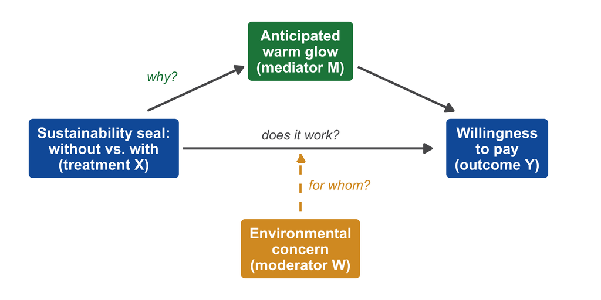

- **H1 · Does it work?** Willingness to pay is higher with the seal than without it
- **H2 · For whom?** The difference increases with environmental concern: a seal means more to people who care about what it certifies (Sörqvist et al. 2013)
- **H3 · Why?** The effect runs through the anticipated *warm glow* — the good feeling of contributing to something good (Hartmann & Apaolaza-Ibáñez 2012)

The hypotheses, the main analysis, the sample size, and the exclusion rules were written down before the first response came in.

## The design: one product page, without or with the seal

**Control** (*n* = 61)

[figure not shown]

**Seal** (*n* = 59)

[figure not shown]

**A between-subjects experiment in Qualtrics:** the randomizer showed each respondent one of the two pages. The seal is the only difference. Brand and seal are fictitious, and no price is shown.

## What we measured

| Variable | Role | Measure | Asked |
| --- | --- | --- | --- |
| **Environmental concern** | Moderator | 3 statements of the revised NEP scale (Dunlap et al. 2000), 1–7 · α = 0.82 | before the page |
| **Sustainability seal** | Treatment | the product page without or with the seal, assigned at random | — |
| **Anticipated warm glow** | Mediator | 3 statements adapted from Hartmann & Apaolaza-Ibáñez (2012), 1–7 · α = 0.77 | after the page |
| **Willingness to pay** | Outcome | “What is the most you would be willing to pay for a 250 g pack of this coffee?” (euros) | after the mediator |
| Seal noticed | Manipulation check | “The coffee on the product page carried a seal for sustainable farming.” 1–7 | after the outcome |
| Cups per day, age, gender | Description | single questions | first and last page |

**An example (warm glow):** “With this coffee, I can feel good because I help to protect the environment.” A scale value is the mean of its three statements; all items are in the appendix (A2).

## The sample: 120 respondents in two comparable groups

- **Planned:** 64 per condition, to detect 1 euro (*d* = 0.5) with 80% power · **reached:** 61 and 59
- **Who:** friends, family, and fellow students, December 1 to 12, one anonymous link
- **144 recorded responses → 120 in the analysis.** Four rules fixed in advance removed 3 previews, 12 unfinished questionnaires, 4 failed attention checks, and 4 speeders; 1 impossible value (85 euros)
- Age 19 to 68 (median 28) · 63 women, 51 men, 6 other or not stated · 2.0 cups of coffee per day

|  | Control | Seal |
| --- | --- | --- |
| Respondents | 61 | 59 |
| Age (mean) | 34.8 | 32.8 |
| Women | 48% | 58% |
| Cups of coffee per day | 1.9 | 2.1 |
| Environmental concern (1–7) | 4.4 | 4.4 |
| **Seal noticed (1–7)** | **2.5** | **5.7** |

**Randomization produced similar groups, and respondents noticed the seal:** +3.2 scale points, 95% CI [2.8; 3.7]. Nobody was excluded on the manipulation check.

## Does it work? Willingness to pay rises by 1.27 euros

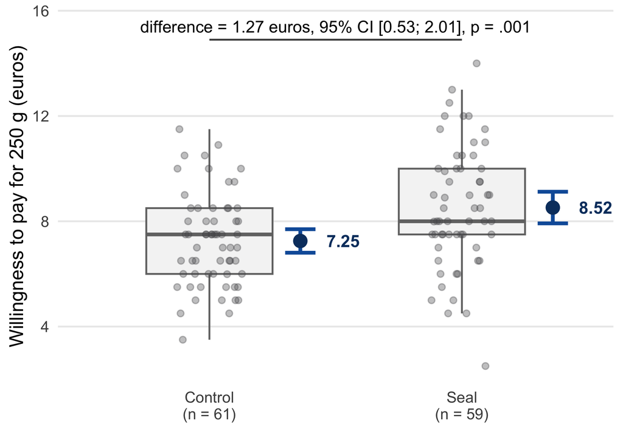

Each dot is one respondent; boxes show the median and the quartiles. Blue: group means with 95% confidence intervals.

$$\text{WTP}_i = \beta_0 + \beta_1\,\text{Seal}_i + \varepsilon_i$$

- With the seal: **8.52 euros** · without: 7.25 euros
- Difference: **+1.27 euros** (+18%), 95% CI [0.53; 2.01]
- *t*(108) = 3.39, *p* = .001; effect size *d* = 0.63
- Welch *t*-test: two independent groups, equal variances not assumed

**H1 is supported.** The interval is wide: the premium could be 0.5 euros — or 2.0.

## For whom? The effect tends to grow with environmental concern

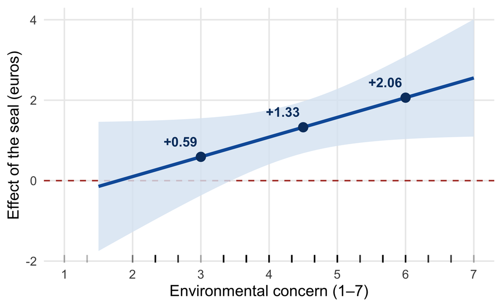

*n* = 120 · band: 95% confidence interval · marks on the axis: the respondents

$$\begin{aligned}\text{WTP}_i = {} & \beta_0 + \beta_1\,\text{Seal}_i + \beta_2\,\text{Concern}_i \\ & + \beta_3\,(\text{Seal}_i \times \text{Concern}_i) + \varepsilon_i\end{aligned}$$

| Environmental concern | Effect of the seal (euros) | 95% CI |
| --- | --- | --- |
| 3 (low) | +0.59 | [−0.37; 1.55] |
| 4.5 (middle) | +1.33 | [0.68; 1.97] |
| 6 (high) | +2.06 | [1.03; 3.09] |

**In line with H2, but not established:** the effect grows by β<sub>3</sub> = 0.49 euros per scale point, 95% CI [−0.02; 1.00], *p* = .057. With 120 respondents, we cannot rule out that the seal works equally well for everyone.

## Why? About 80% of the effect runs through the warm glow

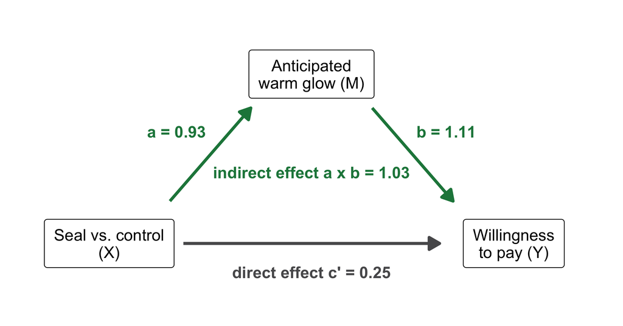

*n* = 120 · coefficients of the two regressions below

$$\text{Glow}_i = \alpha_0 + a\,\text{Seal}_i + \alpha_2\,\text{Concern}_i + u_i$$

$$\text{WTP}_i = \beta_0 + c'\,\text{Seal}_i + b\,\text{Glow}_i + \beta_3\,\text{Concern}_i + \varepsilon_i$$

- The seal raises the anticipated warm glow by **0.93 scale points** (path *a*)
- One point more warm glow goes with **1.11 euros** more willingness to pay (path *b*)
- **Indirect effect *a* × *b* = 1.03 euros**, bootstrap 95% CI [0.62; 1.50] — about 80% of the total effect of 1.28 euros
- Direct effect: 0.25 euros, 95% CI [−0.36; 0.85]

**H3 is supported** — if nothing unobserved drives both the warm glow and the willingness to pay. Environmental concern is adjusted for.

## What this study cannot tell

|  | The limitation | What it means |
| --- | --- | --- |
| **Sample** | 120 friends, family members, and fellow students | They are not Sierra Verde’s customers: the effect holds among people like our respondents |
| **Outcome** | Stated willingness to pay — no purchase | Surveys overstate what people pay; what we interpret is the difference between the groups |
| **Stimulus** | One product page and a seal that does not exist | A real seal comes with a reputation — which can help or hurt |
| **Mechanism** | Warm glow was measured, not manipulated | Expected taste and trust in the brand were not measured and may play a role as well |
| **Moderator** | About 60 respondents per group | Too few for a firm answer to *for whom* |

## Recommendation: certify if the seal costs less than 0.53 euros per pack

**Does the seal pay off?** That depends on what the certification costs per pack:

| Cost per pack | Our recommendation |
| --- | --- |
| below 0.53 euros | **Certify.** Even at the lower end of our interval, the premium covers the cost |
| 0.53 to 1.27 euros | **Start with a pilot:** certify one coffee and test the seal in the shop |
| above 1.27 euros | **Do not certify:** the cost exceeds the premium we estimate |

**How to use the seal**

- **Show it where it cannot be missed** — on the product picture, as in our test
- **Say what a purchase achieves:** the premium comes with the good feeling of doing something good
- **Do not target yet:** the seal seems to matter most to environmentally concerned customers, but this is not established

**The next experiment** — in the shop, with real prices and purchases: the page of one certified coffee without the seal, with the seal, and with the seal plus one sentence on what a purchase achieves.

# Appendix

## A1 · From the export to the analysis sample

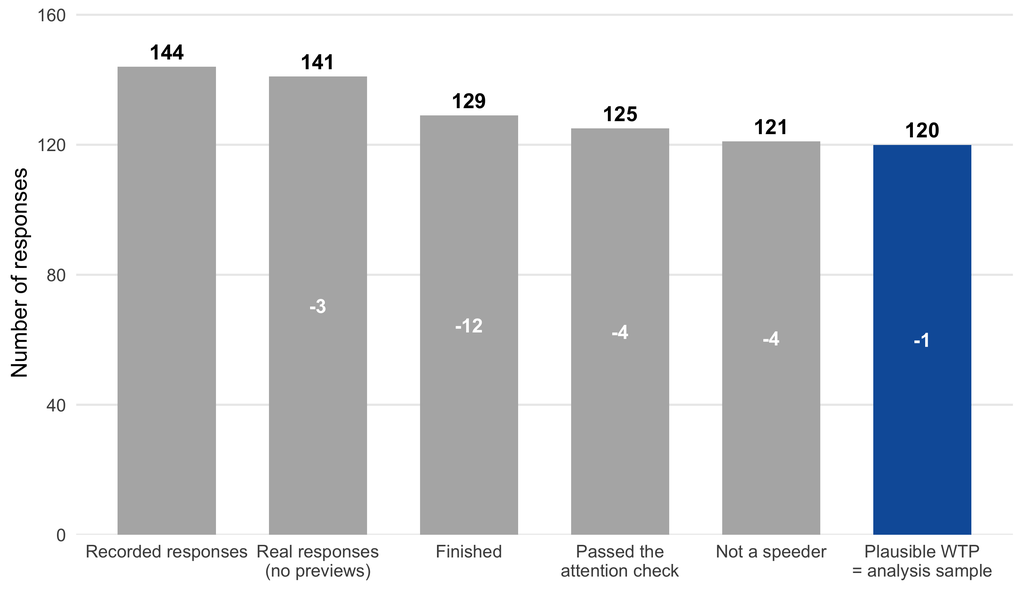

**Four rules, fixed before the data collection**

1. No previews and tests
2. Only finished questionnaires
3. Attention check passed (asked *before* the product page)
4. No speeders: at least one third of the median duration

**Not planned:** one respondent entered 85 euros for the pack — an impossible value, set to missing.

The manipulation check was **not** used to exclude respondents. Median duration: 5.7 minutes.

## A2 · The scales: items and reliability

| Statement | Mean | SD | Correlation with the other two |
| --- | --- | --- | --- |
| **Environmental concern** (moderator) · Cronbach’s α = 0.82 |  |  |  |
| Humans are severely abusing the environment. | 4.41 | 1.41 | .67 |
| The so-called “ecological crisis” facing humankind has been greatly exaggerated. *(reverse-scored)* | 4.67 | 1.49 | .67 |
| If things continue on their present course, we will soon experience a major ecological catastrophe. | 4.16 | 1.59 | .67 |
| **Anticipated warm glow** (mediator) · Cronbach’s α = 0.77 |  |  |  |
| With this coffee, I can feel good because I help to protect the environment. | 4.58 | 1.34 | .61 |
| With this coffee, I can feel better because I do not harm the environment. | 4.24 | 1.42 | .62 |
| With this coffee, I have the feeling of contributing to the well-being of humanity and nature. | 4.58 | 1.17 | .60 |

1 = strongly disagree … 7 = strongly agree; the reverse-scored statement was recoded (8 minus the answer). Sources: Dunlap et al. (2000); Hartmann & Apaolaza-Ibáñez (2012), adapted.

## A3 · Regression tables: H1 and H2

**H1** · willingness to pay (euros)

|  | Estimate | SE | 95% CI | *p* |
| --- | --- | --- | --- | --- |
| Intercept | 7.25 | 0.26 | [6.74; 7.77] | < .001 |
| Seal | 1.27 | 0.37 | [0.53; 2.01] | .001 |

*n* = 120, *R*² = 0.09

**H2** · willingness to pay (euros)

|  | Estimate | SE | 95% CI | *p* |
| --- | --- | --- | --- | --- |
| Intercept | 5.04 | 0.86 | [3.34; 6.73] | < .001 |
| Seal | −0.88 | 1.17 | [−3.20; 1.44] | .455 |
| Concern | 0.50 | 0.19 | [0.13; 0.87] | .008 |
| Seal × Concern | 0.49 | 0.26 | [−0.02; 1.00] | .057 |

*n* = 120, *R*² = 0.32

Seal: 0 = control, 1 = seal. Concern: the mean of three statements (1–7). In the H2 model, the coefficient of *Seal* is the effect at a concern of 0, a value outside the scale — the effects at a concern of 3, 4.5, and 6 are on slide 8.

## A4 · Regression tables: H3 (mediation)

**Mediator model** · warm glow (1–7)

|  | Estimate | SE | 95% CI | *p* |
| --- | --- | --- | --- | --- |
| Intercept | 2.85 | 0.32 | [2.22; 3.48] | < .001 |
| Seal (*a*) | 0.93 | 0.17 | [0.59; 1.27] | < .001 |
| Concern | 0.26 | 0.07 | [0.13; 0.40] | < .001 |

*n* = 120, *R*² = 0.28

**Outcome model** · willingness to pay (euros)

|  | Estimate | SE | 95% CI | *p* |
| --- | --- | --- | --- | --- |
| Intercept | 0.73 | 0.65 | [−0.57; 2.02] | .270 |
| Seal (*c′*) | 0.25 | 0.30 | [−0.34; 0.85] | .403 |
| Warm glow (*b*) | 1.11 | 0.15 | [0.82; 1.40] | < .001 |
| Concern | 0.47 | 0.11 | [0.25; 0.70] | < .001 |

*n* = 120, *R*² = 0.53

**Mediation analysis with `mediate()`** (R package *mediation*, Tingley et al. 2014; percentile bootstrap, 1,000 resamples): indirect effect *a* × *b* = 0.93 × 1.11 = **1.03 euros**, 95% CI [0.62; 1.50] · direct effect 0.25 [−0.36; 0.85] · total effect 1.28 [0.63; 1.91] · share mediated 0.80 [0.51; 1.48]. The share is a ratio of two estimates and therefore imprecise; the intervals of the two regression tables are not bootstrapped and differ slightly.

## A5 · Is the main result robust?

| Analysis | *n* | Difference (euros) | 95% CI | *p* |
| --- | --- | --- | --- | --- |
| **Main analysis:** Welch *t*-test | 120 | +1.27 | [0.53; 2.01] | .001 |
| Wilcoxon rank-sum test (no assumption about the distribution) | 120 | — | — | .001 |
| All finished respondents — without the attention-check and the speeder rule | 128 | +1.19 | [0.46; 1.92] | .002 |

- **Unequal spread:** the standard deviation is 1.74 euros without and 2.31 euros with the seal — the Welch test does not assume equal variances
- **Not normally distributed?** With about 60 respondents per group, the test of the means does not depend on it; the rank-based test leads to the same conclusion
- **The exclusion rules do not drive the result:** it is nearly the same for all finished respondents
- Rows 2 and 3 were **not planned in advance**: they are robustness checks, not new tests of H1

## A6 · The questionnaire

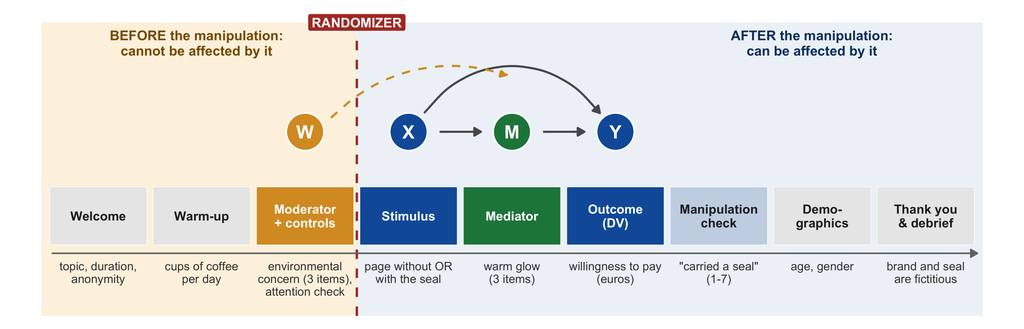

Twelve questions in Qualtrics. The randomizer contains two groups; each stores the condition in the data (`condition` = `Control` or `Seal`) and shows its product page. Everything else is identical for all respondents.

## References

- Dunlap, R. E., Van Liere, K. D., Mertig, A. G., & Jones, R. E. (2000). Measuring endorsement of the New Ecological Paradigm: A revised NEP scale. *Journal of Social Issues, 56*(3), 425–442.
- Hartmann, P., & Apaolaza-Ibáñez, V. (2012). Consumer attitude and purchase intention toward green energy brands: The roles of psychological benefits and environmental concern. *Journal of Business Research, 65*(9), 1254–1263.
- Sörqvist, P., Hedblom, D., Holmgren, M., Haga, A., Langeborg, L., Nöstl, A., & Kågström, J. (2013). Who needs cream and sugar when there is eco-labeling? Taste and willingness to pay for “eco-friendly” coffee. *PLoS ONE, 8*(12), e80719.
- Tingley, D., Yamamoto, T., Hirose, K., Keele, L., & Imai, K. (2014). mediation: R package for causal mediation analysis. *Journal of Statistical Software, 59*(5), 1–38.

## About this example

| Slides | Point of the guidelines | Minutes |
| --- | --- | --- |
| 1 | Title | 0:15 |
| 2–3 | 1 The problem and the question | 2:00 |
| 4–5 | 2 The design | 1:40 |
| 6 | 3 The sample · 4 The manipulation check | 1:00 |
| 7 | 5 The main result | 1:05 |
| 8 | 6 For whom | 1:10 |
| 9 | 7 Why | 1:05 |
| 10 | 8 Limitations | 0:45 |
| 11 | 9 Recommendations | 1:00 |
|  | **Total** | **10:00** |
| 13–19 | Appendix (not presented) | — |

- **Ten minutes, ten slides** after the title: about one minute per slide — a third of the time for the three results
- **One message per slide.** The title says it; one chart or table shows it; the numbers a critical reader needs stand next to it: estimate, 95% confidence interval, test, effect size, *n*
- **The appendix is for questions:** the exclusions, the item statistics, the regression tables, and the robustness checks
- **Reproducible:** every number and chart is computed from the raw export `coffee_seal_qualtrics.csv`

A model for the structure and the level of detail — not a template to copy. The study, the brand, the seal, and the data are fictitious.